# Ford GoBike System Data Exploration

## by Rahaf Aljehani

1. Introduction
2. Preliminary Wrangling
3. Univariate Exploration
4. Bivariate Exploration
5. Multivariate Exploration
6. Conclusions

## Introduction

> I selected Ford GoBike System dataset for analysis, it includes information about individual rides made in a bike-sharing system covering the greater San Francisco Bay area. This data contains 183412 individual rides with 16 features, these features include duration variables such as:duration in sec, start time and end time, also include users information such as:user type and gender.

## Preliminary Wrangling

> In this section, we understand the data structure for Ford GoBike System dataset, and make preliminary data wrangling, such as changing data types of variabls, or make sure you don't have too many missing or duplicated values, as following:

```python
# import all packages and set plots to be embedded inline
import numpy as np
import pandas as pd
import matplotlib.pyplot as plt
import seaborn as sb

%matplotlib inline
```

```python
# loaded 201902-fordgobike-tripdata.csv dataset
fordgobike_df=pd.read_csv("201902-fordgobike-tripdata.csv")
```

```python
# Display the dataset
fordgobike_df
```

|  | duration_sec | start_time | end_time | start_station_id | start_station_name | start_station_latitude | start_station_longitude | end_station_id | end_station_name | end_station_latitude | end_station_longitude | bike_id | user_type | member_birth_year | member_gender | bike_share_for_all_trip |
| --- | --- | --- | --- | --- | --- | --- | --- | --- | --- | --- | --- | --- | --- | --- | --- | --- |
| 0 | 52185 | 2019-02-28 17:32:10.1450 | 2019-03-01 08:01:55.9750 | 21.0 | Montgomery St BART Station (Market St at 2nd St) | 37.789625 | -122.400811 | 13.0 | Commercial St at Montgomery St | 37.794231 | -122.402923 | 4902 | Customer | 1984.0 | Male | No |
| 1 | 42521 | 2019-02-28 18:53:21.7890 | 2019-03-01 06:42:03.0560 | 23.0 | The Embarcadero at Steuart St | 37.791464 | -122.391034 | 81.0 | Berry St at 4th St | 37.775880 | -122.393170 | 2535 | Customer | NaN | NaN | No |
| 2 | 61854 | 2019-02-28 12:13:13.2180 | 2019-03-01 05:24:08.1460 | 86.0 | Market St at Dolores St | 37.769305 | -122.426826 | 3.0 | Powell St BART Station (Market St at 4th St) | 37.786375 | -122.404904 | 5905 | Customer | 1972.0 | Male | No |
| 3 | 36490 | 2019-02-28 17:54:26.0100 | 2019-03-01 04:02:36.8420 | 375.0 | Grove St at Masonic Ave | 37.774836 | -122.446546 | 70.0 | Central Ave at Fell St | 37.773311 | -122.444293 | 6638 | Subscriber | 1989.0 | Other | No |
| 4 | 1585 | 2019-02-28 23:54:18.5490 | 2019-03-01 00:20:44.0740 | 7.0 | Frank H Ogawa Plaza | 37.804562 | -122.271738 | 222.0 | 10th Ave at E 15th St | 37.792714 | -122.248780 | 4898 | Subscriber | 1974.0 | Male | Yes |
| 5 | 1793 | 2019-02-28 23:49:58.6320 | 2019-03-01 00:19:51.7600 | 93.0 | 4th St at Mission Bay Blvd S | 37.770407 | -122.391198 | 323.0 | Broadway at Kearny | 37.798014 | -122.405950 | 5200 | Subscriber | 1959.0 | Male | No |
| 6 | 1147 | 2019-02-28 23:55:35.1040 | 2019-03-01 00:14:42.5880 | 300.0 | Palm St at Willow St | 37.317298 | -121.884995 | 312.0 | San Jose Diridon Station | 37.329732 | -121.901782 | 3803 | Subscriber | 1983.0 | Female | No |
| 7 | 1615 | 2019-02-28 23:41:06.7660 | 2019-03-01 00:08:02.7560 | 10.0 | Washington St at Kearny St | 37.795393 | -122.404770 | 127.0 | Valencia St at 21st St | 37.756708 | -122.421025 | 6329 | Subscriber | 1989.0 | Male | No |
| 8 | 1570 | 2019-02-28 23:41:48.7900 | 2019-03-01 00:07:59.7150 | 10.0 | Washington St at Kearny St | 37.795393 | -122.404770 | 127.0 | Valencia St at 21st St | 37.756708 | -122.421025 | 6548 | Subscriber | 1988.0 | Other | No |
| 9 | 1049 | 2019-02-28 23:49:47.6990 | 2019-03-01 00:07:17.0250 | 19.0 | Post St at Kearny St | 37.788975 | -122.403452 | 121.0 | Mission Playground | 37.759210 | -122.421339 | 6488 | Subscriber | 1992.0 | Male | No |
| 10 | 458 | 2019-02-28 23:57:57.2110 | 2019-03-01 00:05:35.4350 | 370.0 | Jones St at Post St | 37.787327 | -122.413278 | 43.0 | San Francisco Public Library (Grove St at Hyde... | 37.778768 | -122.415929 | 5318 | Subscriber | 1996.0 | Female | Yes |
| 11 | 506 | 2019-02-28 23:56:55.5400 | 2019-03-01 00:05:21.7330 | 44.0 | Civic Center/UN Plaza BART Station (Market St ... | 37.781074 | -122.411738 | 343.0 | Bryant St at 2nd St | 37.783172 | -122.393572 | 5848 | Subscriber | 1993.0 | Male | No |
| 12 | 1176 | 2019-02-28 23:45:12.6510 | 2019-03-01 00:04:49.1840 | 127.0 | Valencia St at 21st St | 37.756708 | -122.421025 | 323.0 | Broadway at Kearny | 37.798014 | -122.405950 | 5328 | Customer | 1990.0 | Male | No |
| 13 | 915 | 2019-02-28 23:49:06.0620 | 2019-03-01 00:04:21.8670 | 252.0 | Channing Way at Shattuck Ave | 37.865847 | -122.267443 | 244.0 | Shattuck Ave at Hearst Ave | 37.873676 | -122.268487 | 5101 | Subscriber | NaN | NaN | No |
| 14 | 395 | 2019-02-28 23:56:26.8480 | 2019-03-01 00:03:01.9470 | 243.0 | Bancroft Way at College Ave | 37.869360 | -122.254337 | 252.0 | Channing Way at Shattuck Ave | 37.865847 | -122.267443 | 4786 | Subscriber | 1988.0 | Male | No |
| 15 | 208 | 2019-02-28 23:59:18.5480 | 2019-03-01 00:02:47.2280 | 349.0 | Howard St at Mary St | 37.781010 | -122.405666 | 60.0 | 8th St at Ringold St | 37.774520 | -122.409449 | 6361 | Subscriber | 1993.0 | Male | Yes |
| 16 | 548 | 2019-02-28 23:50:41.6070 | 2019-02-28 23:59:49.9530 | 131.0 | 22nd St at Dolores St | 37.755000 | -122.425728 | 71.0 | Broderick St at Oak St | 37.773063 | -122.439078 | 6572 | Subscriber | 1981.0 | Male | No |
| 17 | 674 | 2019-02-28 23:48:25.0950 | 2019-02-28 23:59:40.0920 | 74.0 | Laguna St at Hayes St | 37.776435 | -122.426244 | 336.0 | Potrero Ave and Mariposa St | 37.763281 | -122.407377 | 5343 | Subscriber | 1975.0 | Male | No |
| 18 | 557 | 2019-02-28 23:49:01.8510 | 2019-02-28 23:58:19.8090 | 321.0 | 5th St at Folsom | 37.780146 | -122.403071 | 75.0 | Market St at Franklin St | 37.773793 | -122.421239 | 5854 | Subscriber | 1990.0 | Male | No |
| 19 | 874 | 2019-02-28 23:43:05.1830 | 2019-02-28 23:57:39.7960 | 180.0 | Telegraph Ave at 23rd St | 37.812678 | -122.268773 | 180.0 | Telegraph Ave at 23rd St | 37.812678 | -122.268773 | 5629 | Customer | 1978.0 | Male | No |
| 20 | 417 | 2019-02-28 23:50:38.2390 | 2019-02-28 23:57:35.8520 | 72.0 | Page St at Scott St | 37.772406 | -122.435650 | 107.0 | 17th St at Dolores St | 37.763015 | -122.426497 | 4999 | Subscriber | 1983.0 | Male | No |
| 21 | 414 | 2019-02-28 23:50:26.8790 | 2019-02-28 23:57:21.1300 | 163.0 | Lake Merritt BART Station | 37.797320 | -122.265320 | 221.0 | 6th Ave at E 12th St (Temporary Location) | 37.794396 | -122.253842 | 6007 | Subscriber | 1984.0 | Male | Yes |
| 22 | 743 | 2019-02-28 23:44:56.4390 | 2019-02-28 23:57:20.2120 | 370.0 | Jones St at Post St | 37.787327 | -122.413278 | 52.0 | McAllister St at Baker St | 37.777416 | -122.441838 | 5479 | Subscriber | 1991.0 | Female | No |
| 23 | 367 | 2019-02-28 23:51:06.0140 | 2019-02-28 23:57:13.3120 | 243.0 | Bancroft Way at College Ave | 37.869360 | -122.254337 | 269.0 | Telegraph Ave at Carleton St | 37.862320 | -122.258801 | 1804 | Subscriber | 1997.0 | Female | No |
| 24 | 252 | 2019-02-28 23:52:51.1640 | 2019-02-28 23:57:03.9760 | 190.0 | West St at 40th St | 37.830223 | -122.270950 | 189.0 | Genoa St at 55th St | 37.839649 | -122.271756 | 5678 | Subscriber | 1975.0 | Male | No |
| 25 | 360 | 2019-02-28 23:50:31.4310 | 2019-02-28 23:56:31.8910 | 163.0 | Lake Merritt BART Station | 37.797320 | -122.265320 | 196.0 | Grand Ave at Perkins St | 37.808894 | -122.256460 | 6240 | Subscriber | 1986.0 | Male | No |
| 26 | 385 | 2019-02-28 23:49:24.3990 | 2019-02-28 23:55:50.2840 | 6.0 | The Embarcadero at Sansome St | 37.804770 | -122.403234 | 15.0 | San Francisco Ferry Building (Harry Bridges Pl... | 37.795392 | -122.394203 | 6531 | Customer | 2000.0 | Male | No |
| 27 | 408 | 2019-02-28 23:48:08.2820 | 2019-02-28 23:54:56.9300 | 78.0 | Folsom St at 9th St | 37.773717 | -122.411647 | 78.0 | Folsom St at 9th St | 37.773717 | -122.411647 | 5410 | Subscriber | 1982.0 | Male | No |
| 28 | 650 | 2019-02-28 23:43:27.5030 | 2019-02-28 23:54:18.4510 | 258.0 | University Ave at Oxford St | 37.872355 | -122.266447 | 263.0 | Channing Way at San Pablo Ave | 37.862827 | -122.290230 | 4784 | Customer | NaN | NaN | No |
| 29 | 629 | 2019-02-28 23:43:48.6580 | 2019-02-28 23:54:18.2540 | 258.0 | University Ave at Oxford St | 37.872355 | -122.266447 | 263.0 | Channing Way at San Pablo Ave | 37.862827 | -122.290230 | 363 | Subscriber | 1995.0 | Male | No |
| ... | ... | ... | ... | ... | ... | ... | ... | ... | ... | ... | ... | ... | ... | ... | ... | ... |
| 183382 | 961 | 2019-02-01 00:38:29.9040 | 2019-02-01 00:54:31.7320 | 95.0 | Sanchez St at 15th St | 37.766219 | -122.431060 | 324.0 | Union Square (Powell St at Post St) | 37.788300 | -122.408531 | 1565 | Subscriber | 1988.0 | Male | No |
| 183383 | 434 | 2019-02-01 00:47:11.6530 | 2019-02-01 00:54:26.3050 | 274.0 | Oregon St at Adeline St | 37.857567 | -122.267558 | 244.0 | Shattuck Ave at Hearst Ave | 37.873676 | -122.268487 | 4541 | Customer | 1997.0 | Male | No |
| 183384 | 184 | 2019-02-01 00:50:41.5790 | 2019-02-01 00:53:46.1240 | 316.0 | San Salvador St at 1st St | 37.330165 | -121.885831 | 298.0 | Oak St at 1st St | 37.322125 | -121.881090 | 4044 | Subscriber | 1991.0 | Male | No |
| 183385 | 400 | 2019-02-01 00:46:47.2760 | 2019-02-01 00:53:27.5960 | 220.0 | San Pablo Ave at MLK Jr Way | 37.811351 | -122.273422 | 337.0 | Webster St at 19th St | 37.806970 | -122.266588 | 3487 | Subscriber | 1945.0 | Male | Yes |
| 183386 | 425 | 2019-02-01 00:42:20.4720 | 2019-02-01 00:49:25.5150 | 239.0 | Bancroft Way at Telegraph Ave | 37.868813 | -122.258764 | 245.0 | Downtown Berkeley BART | 37.870139 | -122.268422 | 1377 | Subscriber | 1998.0 | Male | Yes |
| 183387 | 598 | 2019-02-01 00:39:12.6840 | 2019-02-01 00:49:10.7910 | 239.0 | Bancroft Way at Telegraph Ave | 37.868813 | -122.258764 | 245.0 | Downtown Berkeley BART | 37.870139 | -122.268422 | 2055 | Subscriber | 1999.0 | Male | Yes |
| 183388 | 490 | 2019-02-01 00:39:53.1120 | 2019-02-01 00:48:03.3380 | 61.0 | Howard St at 8th St | 37.776513 | -122.411306 | 81.0 | Berry St at 4th St | 37.775880 | -122.393170 | 5411 | Subscriber | 1927.0 | Male | No |
| 183389 | 184 | 2019-02-01 00:43:56.5560 | 2019-02-01 00:47:01.0090 | 66.0 | 3rd St at Townsend St | 37.778742 | -122.392741 | 47.0 | 4th St at Harrison St | 37.780955 | -122.399749 | 4960 | Subscriber | 1985.0 | Other | No |
| 183390 | 232 | 2019-02-01 00:40:00.0350 | 2019-02-01 00:43:52.8800 | 239.0 | Bancroft Way at Telegraph Ave | 37.868813 | -122.258764 | 266.0 | Parker St at Fulton St | 37.862464 | -122.264791 | 3756 | Subscriber | 1999.0 | Male | No |
| 183391 | 269 | 2019-02-01 00:37:47.5270 | 2019-02-01 00:42:17.0600 | 119.0 | 18th St at Noe St | 37.761047 | -122.432642 | 85.0 | Church St at Duboce Ave | 37.770083 | -122.429156 | 5540 | Subscriber | 1980.0 | Male | Yes |
| 183392 | 1289 | 2019-02-01 00:19:45.6410 | 2019-02-01 00:41:15.5580 | 8.0 | The Embarcadero at Vallejo St | 37.799953 | -122.398525 | 350.0 | 8th St at Brannan St | 37.771431 | -122.405787 | 3506 | Subscriber | 1993.0 | Male | No |
| 183393 | 155 | 2019-02-01 00:37:26.3680 | 2019-02-01 00:40:01.5760 | 116.0 | Mississippi St at 17th St | 37.764802 | -122.394771 | 93.0 | 4th St at Mission Bay Blvd S | 37.770407 | -122.391198 | 5406 | Subscriber | 1985.0 | Male | No |
| 183394 | 720 | 2019-02-01 00:27:33.8340 | 2019-02-01 00:39:34.2330 | 26.0 | 1st St at Folsom St | 37.787290 | -122.394380 | 96.0 | Dolores St at 15th St | 37.766210 | -122.426614 | 5331 | Subscriber | 1975.0 | Male | No |
| 183395 | 95 | 2019-02-01 00:37:23.1150 | 2019-02-01 00:38:58.3460 | 276.0 | Julian St at The Alameda | 37.332233 | -121.912517 | 277.0 | Morrison Ave at Julian St | 37.333658 | -121.908586 | 4299 | Subscriber | 1993.0 | Male | Yes |
| 183396 | 576 | 2019-02-01 00:27:06.5030 | 2019-02-01 00:36:43.4520 | 181.0 | Grand Ave at Webster St | 37.811377 | -122.265192 | 212.0 | Mosswood Park | 37.824893 | -122.260437 | 3561 | Subscriber | 1991.0 | Male | Yes |
| 183397 | 438 | 2019-02-01 00:28:56.1010 | 2019-02-01 00:36:14.5340 | 62.0 | Victoria Manalo Draves Park | 37.777791 | -122.406432 | 59.0 | S Van Ness Ave at Market St | 37.774814 | -122.418954 | 5531 | Subscriber | 1988.0 | Male | No |
| 183398 | 1019 | 2019-02-01 00:16:59.1550 | 2019-02-01 00:33:58.5900 | 339.0 | Jackson St at 11th St | 37.800002 | -122.266438 | 46.0 | San Antonio Park | 37.790140 | -122.242373 | 3233 | Subscriber | 1982.0 | Male | No |
| 183399 | 958 | 2019-02-01 00:12:24.2470 | 2019-02-01 00:28:22.7380 | 67.0 | San Francisco Caltrain Station 2 (Townsend St... | 37.776639 | -122.395526 | 58.0 | Market St at 10th St | 37.776619 | -122.417385 | 3392 | Subscriber | 1993.0 | Male | No |
| 183400 | 250 | 2019-02-01 00:23:52.6110 | 2019-02-01 00:28:02.6790 | 356.0 | Valencia St at Clinton Park | 37.769188 | -122.422285 | 58.0 | Market St at 10th St | 37.776619 | -122.417385 | 4962 | Subscriber | 1984.0 | Male | No |
| 183401 | 383 | 2019-02-01 00:16:48.0620 | 2019-02-01 00:23:11.2010 | 186.0 | Lakeside Dr at 14th St | 37.801319 | -122.262642 | 181.0 | Grand Ave at Webster St | 37.811377 | -122.265192 | 4505 | Subscriber | 1991.0 | Male | Yes |
| 183402 | 122 | 2019-02-01 00:17:32.2580 | 2019-02-01 00:19:34.9380 | 119.0 | 18th St at Noe St | 37.761047 | -122.432642 | 120.0 | Mission Dolores Park | 37.761420 | -122.426435 | 4326 | Subscriber | NaN | NaN | No |
| 183403 | 249 | 2019-02-01 00:15:12.0670 | 2019-02-01 00:19:21.6990 | 256.0 | Hearst Ave at Euclid Ave | 37.875112 | -122.260553 | 247.0 | Fulton St at Bancroft Way | 37.867789 | -122.265896 | 4642 | Subscriber | 2000.0 | Male | No |
| 183404 | 256 | 2019-02-01 00:12:50.5540 | 2019-02-01 00:17:07.3620 | 241.0 | Ashby BART Station | 37.852477 | -122.270213 | 248.0 | Telegraph Ave at Ashby Ave | 37.855956 | -122.259795 | 4845 | Subscriber | 1980.0 | Male | Yes |
| 183405 | 111 | 2019-02-01 00:14:49.8740 | 2019-02-01 00:16:41.3010 | 324.0 | Union Square (Powell St at Post St) | 37.788300 | -122.408531 | 19.0 | Post St at Kearny St | 37.788975 | -122.403452 | 4832 | Subscriber | 1984.0 | Male | No |
| 183406 | 706 | 2019-02-01 00:04:40.6160 | 2019-02-01 00:16:27.0800 | 138.0 | Jersey St at Church St | 37.750900 | -122.427411 | 78.0 | Folsom St at 9th St | 37.773717 | -122.411647 | 5017 | Subscriber | 1988.0 | Male | No |
| 183407 | 480 | 2019-02-01 00:04:49.7240 | 2019-02-01 00:12:50.0340 | 27.0 | Beale St at Harrison St | 37.788059 | -122.391865 | 324.0 | Union Square (Powell St at Post St) | 37.788300 | -122.408531 | 4832 | Subscriber | 1996.0 | Male | No |
| 183408 | 313 | 2019-02-01 00:05:34.7440 | 2019-02-01 00:10:48.5020 | 21.0 | Montgomery St BART Station (Market St at 2nd St) | 37.789625 | -122.400811 | 66.0 | 3rd St at Townsend St | 37.778742 | -122.392741 | 4960 | Subscriber | 1984.0 | Male | No |
| 183409 | 141 | 2019-02-01 00:06:05.5490 | 2019-02-01 00:08:27.2200 | 278.0 | The Alameda at Bush St | 37.331932 | -121.904888 | 277.0 | Morrison Ave at Julian St | 37.333658 | -121.908586 | 3824 | Subscriber | 1990.0 | Male | Yes |
| 183410 | 139 | 2019-02-01 00:05:34.3600 | 2019-02-01 00:07:54.2870 | 220.0 | San Pablo Ave at MLK Jr Way | 37.811351 | -122.273422 | 216.0 | San Pablo Ave at 27th St | 37.817827 | -122.275698 | 5095 | Subscriber | 1988.0 | Male | No |
| 183411 | 271 | 2019-02-01 00:00:20.6360 | 2019-02-01 00:04:52.0580 | 24.0 | Spear St at Folsom St | 37.789677 | -122.390428 | 37.0 | 2nd St at Folsom St | 37.785000 | -122.395936 | 1057 | Subscriber | 1989.0 | Male | No |

183412 rows × 16 columns

```python
# Check for dimensions of the datafram (the number of rows and columns in a dataset)
fordgobike_df.shape
```

```
(183412, 16)
```

```python
# showed a brief summary of the dataframe by using info() method
fordgobike_df.info()
```

```
<class 'pandas.core.frame.DataFrame'>
RangeIndex: 183412 entries, 0 to 183411
Data columns (total 16 columns):
duration_sec               183412 non-null int64
start_time                 183412 non-null object
end_time                   183412 non-null object
start_station_id           183215 non-null float64
start_station_name         183215 non-null object
start_station_latitude     183412 non-null float64
start_station_longitude    183412 non-null float64
end_station_id             183215 non-null float64
end_station_name           183215 non-null object
end_station_latitude       183412 non-null float64
end_station_longitude      183412 non-null float64
bike_id                    183412 non-null int64
user_type                  183412 non-null object
member_birth_year          175147 non-null float64
member_gender              175147 non-null object
bike_share_for_all_trip    183412 non-null object
dtypes: float64(7), int64(2), object(7)
memory usage: 22.4+ MB
```

```python
# provide descriptive statistics for each data column by using describe() method
fordgobike_df.describe()
```

|  | duration_sec | start_station_id | start_station_latitude | start_station_longitude | end_station_id | end_station_latitude | end_station_longitude | bike_id | member_birth_year |
| --- | --- | --- | --- | --- | --- | --- | --- | --- | --- |
| count | 183412.000000 | 183215.000000 | 183412.000000 | 183412.000000 | 183215.000000 | 183412.000000 | 183412.000000 | 183412.000000 | 175147.000000 |
| mean | 726.078435 | 138.590427 | 37.771223 | -122.352664 | 136.249123 | 37.771427 | -122.352250 | 4472.906375 | 1984.806437 |
| std | 1794.389780 | 111.778864 | 0.099581 | 0.117097 | 111.515131 | 0.099490 | 0.116673 | 1664.383394 | 10.116689 |
| min | 61.000000 | 3.000000 | 37.317298 | -122.453704 | 3.000000 | 37.317298 | -122.453704 | 11.000000 | 1878.000000 |
| 25% | 325.000000 | 47.000000 | 37.770083 | -122.412408 | 44.000000 | 37.770407 | -122.411726 | 3777.000000 | 1980.000000 |
| 50% | 514.000000 | 104.000000 | 37.780760 | -122.398285 | 100.000000 | 37.781010 | -122.398279 | 4958.000000 | 1987.000000 |
| 75% | 796.000000 | 239.000000 | 37.797280 | -122.286533 | 235.000000 | 37.797320 | -122.288045 | 5502.000000 | 1992.000000 |
| max | 85444.000000 | 398.000000 | 37.880222 | -121.874119 | 398.000000 | 37.880222 | -121.874119 | 6645.000000 | 2001.000000 |

```python
# Check for missing data by using isnull() method
fordgobike_df.isnull().sum()
```

```
duration_sec                  0
start_time                    0
end_time                      0
start_station_id            197
start_station_name          197
start_station_latitude        0
start_station_longitude       0
end_station_id              197
end_station_name            197
end_station_latitude          0
end_station_longitude         0
bike_id                       0
user_type                     0
member_birth_year          8265
member_gender              8265
bike_share_for_all_trip       0
dtype: int64
```

```python
# Drop missing values
fordgobike_df.dropna(inplace= True)
# Confirm correction
fordgobike_df.isnull().sum()
```

```
duration_sec               0
start_time                 0
end_time                   0
start_station_id           0
start_station_name         0
start_station_latitude     0
start_station_longitude    0
end_station_id             0
end_station_name           0
end_station_latitude       0
end_station_longitude      0
bike_id                    0
user_type                  0
member_birth_year          0
member_gender              0
bike_share_for_all_trip    0
dtype: int64
```

```python
# Check for duplicates data by using duplicated() method
fordgobike_df.duplicated().sum()
```

```
0
```

```python
# Change start_time and end_time datatype to timestamp datatype
fordgobike_df.start_time=pd.to_datetime(fordgobike_df.start_time)
fordgobike_df.end_time=pd.to_datetime(fordgobike_df.end_time)

# Change start_station_id, end_station_id, bike_id and member_birth_year datatype to integer datatype
fordgobike_df.start_station_id=fordgobike_df.start_station_id.astype(int)
fordgobike_df.end_station_id=fordgobike_df.end_station_id.astype(int)
fordgobike_df.bike_id=fordgobike_df.bike_id.astype(int)
fordgobike_df.member_birth_year=fordgobike_df.member_birth_year.astype(int)

# Confirm correction
fordgobike_df.dtypes
```

```
duration_sec                        int64
start_time                 datetime64[ns]
end_time                   datetime64[ns]
start_station_id                    int64
start_station_name                 object
start_station_latitude            float64
start_station_longitude           float64
end_station_id                      int64
end_station_name                   object
end_station_latitude              float64
end_station_longitude             float64
bike_id                             int64
user_type                          object
member_birth_year                   int64
member_gender                      object
bike_share_for_all_trip            object
dtype: object
```

```python
# Create a function to use value_counts() method
def valueCounts(value):
 return value.value_counts()
```

```python
valueCounts(fordgobike_df.user_type)
```

```
Subscriber    158386
Customer       16566
Name: user_type, dtype: int64
```

```python
valueCounts(fordgobike_df.member_gender)
```

```
Male      130500
Female     40805
Other       3647
Name: member_gender, dtype: int64
```

```python
valueCounts(fordgobike_df.bike_share_for_all_trip)
```

```
No     157606
Yes     17346
Name: bike_share_for_all_trip, dtype: int64
```

```python
fordgobike_df.info()
```

```
<class 'pandas.core.frame.DataFrame'>
Int64Index: 174952 entries, 0 to 183411
Data columns (total 16 columns):
duration_sec               174952 non-null int64
start_time                 174952 non-null datetime64[ns]
end_time                   174952 non-null datetime64[ns]
start_station_id           174952 non-null int64
start_station_name         174952 non-null object
start_station_latitude     174952 non-null float64
start_station_longitude    174952 non-null float64
end_station_id             174952 non-null int64
end_station_name           174952 non-null object
end_station_latitude       174952 non-null float64
end_station_longitude      174952 non-null float64
bike_id                    174952 non-null int64
user_type                  174952 non-null object
member_birth_year          174952 non-null int64
member_gender              174952 non-null object
bike_share_for_all_trip    174952 non-null object
dtypes: datetime64[ns](2), float64(4), int64(5), object(5)
memory usage: 22.7+ MB
```

### What is the structure of your dataset?

> There are 174952 individual rides in the dataset with 16 features which is duration_sec, start_time, end_time, start_station_id, start_station_name, start_station_latitude, start_station_longitude, end_station_id, end_station_name, end_station_latitude, end_station_longitude, bike_id, user_type, member_birth_year, member_gender, bike_share_for_all_trip. For our datatypes, we have 2 datetime, 4 float, 5 integer and 5 object.

### What is/are the main feature(s) of interest in your dataset?

> The main feature that interests me from the dataset is the duration of the trip and the factors that can affect it, such as: users age and gender.

### What features in the dataset do you think will help support your investigation into your feature(s) of interest?

> I believe the following features will help me to support my investigation:
> 1. start_time.
> 2. user_type.
> 3. member_birth_year.
> 4. member_gender.

## Univariate Exploration

> In this section, we investigate distributions of individual variables by asking the following questions:
> 1. What is distribution of trips duration?
> 2. What is distribution of users types?
> 3. What is distribution of user gender?
> 4. What is distribution of users ages?
> 5. What is distribution of trips taken in time of day?
> 6. What is distribution of trips taken in days of the week?
> 7. What is distribution of bike share for all trip?
> 8. What is distribution of start stations and end stations?

I will use ""Question-Visualization-Observations" framework. this framework involves asking a question from the data, creating a visualization to find answers, and then recording observations.

In the following cells I will create a functions to help me :

```python
# Create a function to determine the size of the charts
def size():
  return plt.figure(figsize=[8,5])
```

```python
# Create a function to determine the color of the charts
def color():
  return sb.color_palette()[9]
```

### Question 1: What is distribution of trips duration?

```python
# Distribution of duration_sec variable
# find minimum and maximum bin limits by using describe() method
fordgobike_df.duration_sec.describe()
```

```
count    174952.000000
mean        704.002744
std        1642.204905
min          61.000000
25%         323.000000
50%         510.000000
75%         789.000000
max       84548.000000
Name: duration_sec, dtype: float64
```

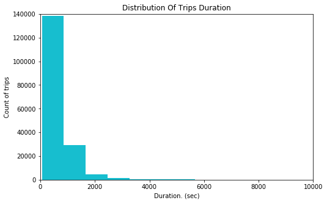

```python
# Plot a histogram for numeric variable.
size() # call size() function
bins=np.arange(61, fordgobike_df["duration_sec"].max()+800,800)
plt.hist(data=fordgobike_df, x="duration_sec",color=color(),bins=bins);
plt.title("Distribution Of Trips Duration")
plt.xlabel('Duration. (sec)')
plt.ylabel("Count of trips")
plt.axis([0,10000, 0,140000])
plt.show()
```

As shown in above histogram chart, distribution of trips duration are so skewed, to fix this problem I will use a log transformation on the x-axis as following in the next cells:

```python
# Transform the describe() to a scale of log10
np.log10(fordgobike_df['duration_sec'].describe())
```

```
count    5.242919
mean     2.847574
std      3.215427
min      1.785330
25%      2.509203
50%      2.707570
75%      2.897077
max      4.927103
Name: duration_sec, dtype: float64
```

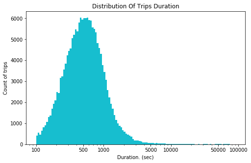

```python
# Use a log transformation on the x-axis
# Plot a histogram for numeric variable
size() # call size() function
bins= 10 ** np.arange(2,np.log10(fordgobike_df['duration_sec'].max())+0.025,0.025)
plt.hist(data=fordgobike_df, x="duration_sec",color=color(),bins=bins);
plt.title("Distribution Of Trips Duration")
plt.xlabel('Duration. (sec)')
plt.ylabel("Count of trips")
plt.xscale('log')
plt.xticks([100,500,1000,5000,10000,50000,100000], [100,500,1000,5000,10000,50000,100000]);
plt.show()
```

### Question 2: What is distribution of users types?

```
Text(0,0.5,'Count of user type')
```

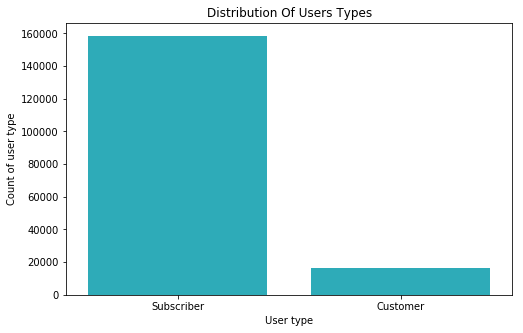

```python
# Distribution of user_type variable
# Plot bar chart for categorical variable
size() # call size() function
order_user_type=fordgobike_df.user_type.value_counts().index
sb.countplot(data=fordgobike_df, x="user_type",color=color(), order=order_user_type);
plt.title("Distribution Of Users Types")
plt.xlabel('User type')
plt.ylabel("Count of user type")
```

As shown in above bar chart,the number of subscriber users is more than the number of customer users.

### Question 3: What is distribution of user gender?

```
Text(0,0.5,'Count of user gender')
```

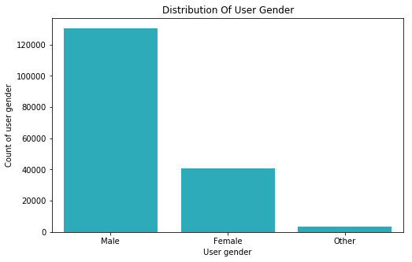

```python
# Distribution of member_gender variable
# Plot bar chart for categorical variable
size() # call size() function
order_member_gender=fordgobike_df.member_gender.value_counts().index
sb.countplot(data=fordgobike_df, x="member_gender",color=color(), order=order_member_gender);
plt.title("Distribution Of User Gender")
plt.xlabel('User gender')
plt.ylabel("Count of user gender")
```

As shown in above bar chart,the number of male users is more than the number of female users.

### Question 4: What is distribution of users ages?

For this question we need to extract the ages of users from member_birth_year variable as following:

```python
# We need to create a new column called user_age to compute the ages of users from member_birth_year variable
# By subtracting 2019 from member_birth_year column
fordgobike_df["user_age"]= 2019 - fordgobike_df["member_birth_year"]
fordgobike_df.sample(1)
```

|  | duration_sec | start_time | end_time | start_station_id | start_station_name | start_station_latitude | start_station_longitude | end_station_id | end_station_name | end_station_latitude | end_station_longitude | bike_id | user_type | member_birth_year | member_gender | bike_share_for_all_trip | user_age |
| --- | --- | --- | --- | --- | --- | --- | --- | --- | --- | --- | --- | --- | --- | --- | --- | --- | --- |
| 71415 | 859 | 2019-02-19 17:23:45.236 | 2019-02-19 17:38:04.805 | 9 | Broadway at Battery St | 37.798572 | -122.400869 | 50 | 2nd St at Townsend St | 37.780526 | -122.390288 | 2868 | Subscriber | 1983 | Male | No | 36 |

```python
# Distribution of member_birth_year variable
# find minimum and maximum bin limits by using describe() method
fordgobike_df.user_age.describe()
```

```
count    174952.000000
mean         34.196865
std          10.118731
min          18.000000
25%          27.000000
50%          32.000000
75%          39.000000
max         141.000000
Name: user_age, dtype: float64
```

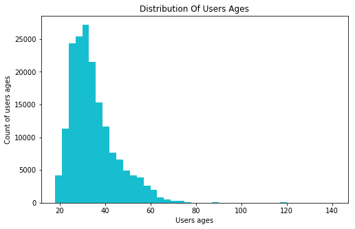

```python
# Plot a histogram for numeric variable.
size() # call size() function
bins=np.arange(18, fordgobike_df["user_age"].max()+3,3)
plt.hist(data=fordgobike_df, x="user_age",color=color(), bins=bins);
plt.title("Distribution Of Users Ages")
plt.xlabel('Users ages')
plt.ylabel("Count of users ages")
plt.show()
```

As shown in above histogram chart, the most age distribution of users is between 18 and 40 years approximately.

### Question 5: What is distribution of trips taken in time of day?

```python
# We need to create a new column called start_hour
#By extract the hour from start_time column
fordgobike_df['start_hour']= fordgobike_df.start_time.dt.hour
```

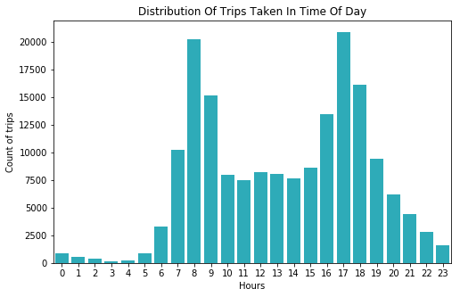

```python
# Plot a bar chart
size() # call size() function
sb.countplot(data=fordgobike_df, x="start_hour",color=color());
plt.title("Distribution Of Trips Taken In Time Of Day")
plt.xlabel('Hours')
plt.ylabel("Count of trips")
plt.show()
```

As shown in above bar chart, the bar chart look like bimodal distributionthe, number of trips increases in the morning at 8 and 9 o'clock, then the number of trips decreases and rises again at 17 and 18 o'clock in the evening.

### Question 6: What is distribution of trips taken in days of the week?

```python
# We need to create a new column called start_day
#By extract the day from start_time column
fordgobike_df['start_day']= fordgobike_df.start_time.dt.strftime('%A')
```

```python
# First we need to order the days
# The order of the days
days =['Monday','Tuesday','Wednesday','Thursday','Friday', 'Saturday', 'Sunday']
order_days= pd.api.types.CategoricalDtype(ordered=True, categories=days)

# Use pandas.astype() to convert the "start_day" column from a object type into an ordered categorical type
fordgobike_df['start_day'] = fordgobike_df['start_day'].astype(order_days);
```

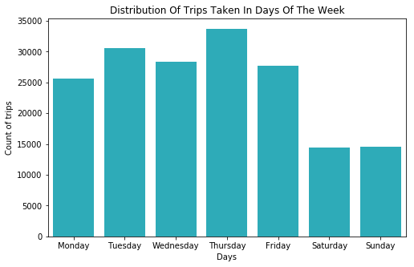

```python
# Plot a bar chart
size() # call size() function
sb.countplot(data=fordgobike_df, x="start_day",color=color());
plt.title("Distribution Of Trips Taken In Days Of The Week")
plt.xlabel('Days')
plt.ylabel("Count of trips")
plt.show()
```

As shown in above bar chart,the number of trips increases on Thursday, and the number of trips decreases on Saturday and Sunday.

### Question 7: What is distribution of bike share for all trip?

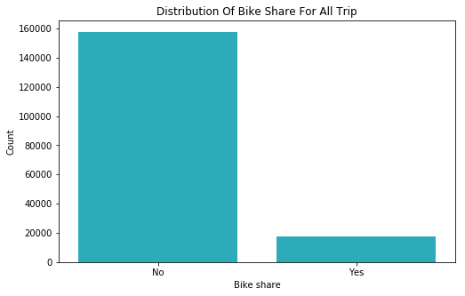

```python
# Plot a bar chart
size() # call size() function
order_bike_share=fordgobike_df.bike_share_for_all_trip.value_counts().index
sb.countplot(data=fordgobike_df, x="bike_share_for_all_trip",color=color(), order=order_bike_share);
plt.title("Distribution Of Bike Share For All Trip")
plt.xlabel('Bike share')
plt.ylabel("Count")
plt.show()
```

As shown in above bar chart, most of the users didn't share bike for all trip.

### Question 8: What is distribution of start stations and end stations?

```python
# Distribution of start stations
# find minimum and maximum bin limits by using describe() method
fordgobike_df.start_station_id.describe()
```

```
count    174952.000000
mean        139.002126
std         111.648819
min           3.000000
25%          47.000000
50%         104.000000
75%         239.000000
max         398.000000
Name: start_station_id, dtype: float64
```

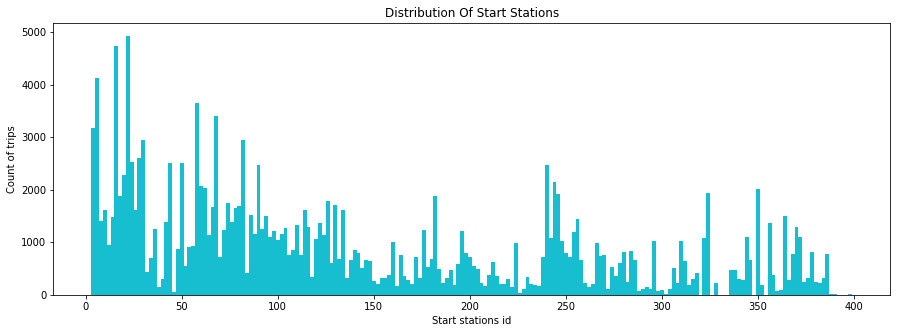

```python
# Plot a histogram for numeric variable.
plt.figure(figsize=[15,5])
bins=np.arange(3, fordgobike_df["start_station_id"].max()+2,2)
plt.hist(data=fordgobike_df, x="start_station_id",color=color(),bins=bins);
plt.title("Distribution Of Start Stations")
plt.xlabel('Start stations id')
plt.ylabel("Count of trips")
plt.show()
```

```python
# Distribution of end stations
# find minimum and maximum bin limits by using describe() method
fordgobike_df.end_station_id.describe()
```

```
count    174952.000000
mean        136.604486
std         111.335635
min           3.000000
25%          44.000000
50%         101.000000
75%         238.000000
max         398.000000
Name: end_station_id, dtype: float64
```

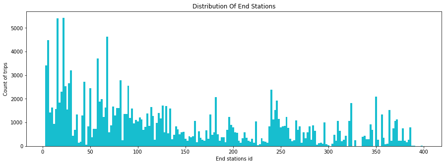

```python
# Plot a histogram for numeric variable.
plt.figure(figsize=[15,5])
bins=np.arange(3, fordgobike_df["end_station_id"].max()+2,2)
plt.hist(data=fordgobike_df, x="end_station_id",color=color(),bins=bins);
plt.title("Distribution Of End Stations")
plt.xlabel('End stations id')
plt.ylabel("Count of trips")
plt.show()
```

As shown in above histogram charts, the distribution of the starting and ending stations is very similar.

### Of the features you investigated, were there any unusual distributions? Did you perform any operations on the data to tidy, adjust, or change the form of the data? If so, why did you do this?

> - Distribution of users ages: we computed the age of users through subtracting 2019 from member_birth_year column to get the age of the users.
> - Distribution of trips taken in time of day: We created a new column called start_hour by extract the hour from start_time column to determine the hours that got the most trips.
> - Distribution of trips taken in days of the week: We created a new column called start_day by extract the day from start_time column to determine the day that got the most trips.
> - Most of the users is subscriber.
> - Most of the users is male.
> - Most of the users didn't share bike for all trip.
> - Most of the users' ages fall between 18 and 40 years approximately.
> - When we compared between distribution of start stations and end stations we got distribution of start stations and end stations is very similar.

## Bivariate Exploration

> In this section, we investigate relationships between pairs of variables by asking the following questions:
> 1. What is the impact of user type on trip duration?
> 2. What is the impact of user gender on trip duration?
> 3. What is the impact of user age on trip duration?
> 4. What is the impact of week days trip on trip duration?
> 5. What is the impact of bike share for all trip on trip duration?
> 6. How users types varies based on days of week, user gender and user bike share for all trip?

I will use ""Question-Visualization-Observations" framework. this framework involves asking a question from the data, creating a visualization to find answers, and then recording observations.

### Question 1: What is the impact of user type on trip duration?

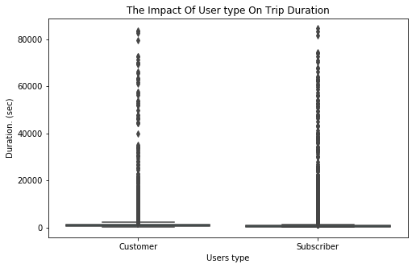

```python
# Plot a box plot
size() # call size() function
sb.boxplot(data=fordgobike_df, x="user_type", y="duration_sec", color=color());
plt.title("The Impact Of User type On Trip Duration")
plt.xlabel('Users type')
plt.ylabel("Duration. (sec)")
plt.show()
```

As shown in above box plot, We need to use the plt.ylim() function to make the y-limits smaller in order for the chart to be properly illustrated.

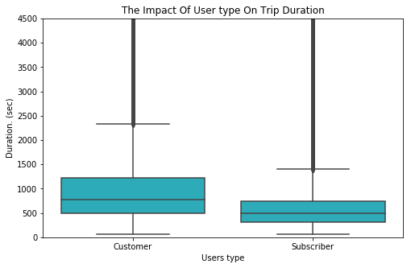

```python
# Plot a box plot
size() # call size() function
sb.boxplot(data=fordgobike_df, x="user_type", y="duration_sec", color=color());
plt.title("The Impact Of User type On Trip Duration")
plt.xlabel('Users type')
plt.ylabel("Duration. (sec)")
plt.ylim([0,4500])
plt.show()
```

As shown in above box plot, customers trip duration take longer than subscribers trip duration.

### Question 2: What is the impact of user gender on trip duration?

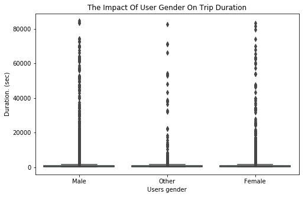

```python
# Plot a box plot
size() # call size() function
sb.boxplot(data=fordgobike_df, x="member_gender", y="duration_sec", color=color());
plt.title("The Impact Of User Gender On Trip Duration")
plt.xlabel('Users gender')
plt.ylabel("Duration. (sec)")
plt.show()
```

As shown in above box plot, We need to use the plt.ylim() function to make the y-limits smaller in order for the chart to be properly illustrated.

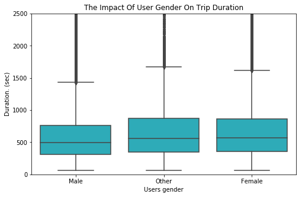

```python
# Plot a box plot
size() # call size() function
sb.boxplot(data=fordgobike_df, x="member_gender", y="duration_sec", color=color());
plt.title("The Impact Of User Gender On Trip Duration")
plt.xlabel('Users gender')
plt.ylabel("Duration. (sec)")
plt.ylim([0,2500])
plt.show()
```

As shown in above box plot, female users trip duration take longer than male users trip duration.

### Question 3: What is the impact of user age on trip duration?

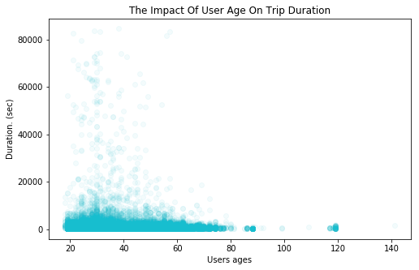

```python
# Plot a scatter plot
size() # call size() function
plt.scatter(data=fordgobike_df, x="user_age", y="duration_sec", color=color(),marker="o",alpha=1/20);
plt.title("The Impact Of User Age On Trip Duration")
plt.xlabel('Users ages')
plt.ylabel("Duration. (sec)")
plt.show()
```

As shown in above scatter plot, We need to use the plt.ylim() function to make the y-limits smaller in order for the chart to be properly illustrated.

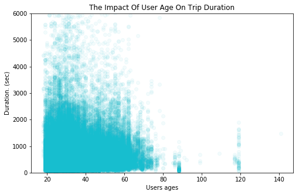

```python
# Plot a scatter plot
size() # call size() function
plt.scatter(data=fordgobike_df, x="user_age", y="duration_sec", color=color(),marker="o",alpha=1/20);
plt.title("The Impact Of User Age On Trip Duration")
plt.xlabel('Users ages')
plt.ylabel("Duration. (sec)")
plt.ylim([0,6000])
plt.show()
```

As shown in above scatter plot, the users who spend more trip duration are between the ages of 18 and 40.

### Question 4: What is the impact of week days trip on trip duration?

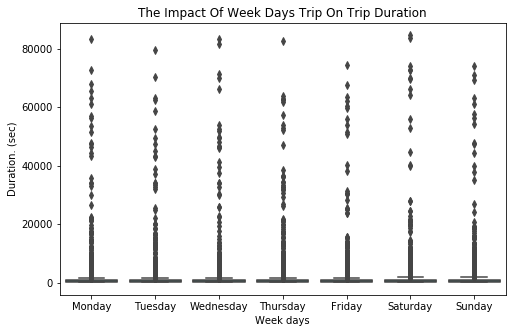

```python
# Plot a box plot
size() # call size() function
sb.boxplot(data=fordgobike_df, x="start_day", y="duration_sec", color=color());
plt.title("The Impact Of Week Days Trip On Trip Duration")
plt.xlabel('Week days')
plt.ylabel("Duration. (sec)")
plt.show()
```

As shown in above box plot, We need to use the plt.ylim() function to make the y-limits smaller in order for the chart to be properly illustrated.

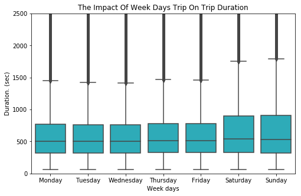

```python
# Plot a box plot
size() # call size() function
sb.boxplot(data=fordgobike_df, x="start_day", y="duration_sec", color=color());
plt.title("The Impact Of Week Days Trip On Trip Duration")
plt.xlabel('Week days')
plt.ylabel("Duration. (sec)")
plt.ylim([0,2500])
plt.show()
```

As shown in above box plot, on Saturday and Sunday, the duration of the trips is longer than the rest of the week

### Question 5: What is the impact of bike share for all trip on trip duration?

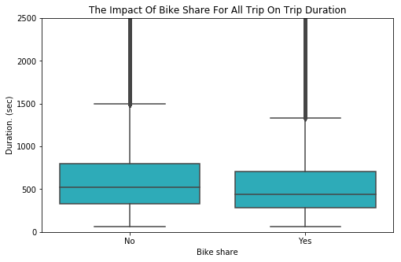

```python
# Plot a box plot
size() # call size() function
sb.boxplot(data=fordgobike_df, x="bike_share_for_all_trip", y="duration_sec", color=color());
plt.title("The Impact Of Bike Share For All Trip On Trip Duration")
plt.xlabel('Bike share')
plt.ylabel("Duration. (sec)")
plt.ylim([0,2500])
plt.show()
```

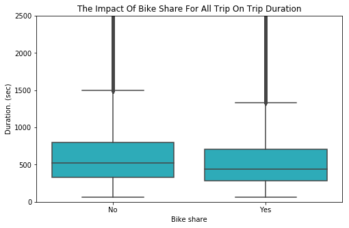

```python
# Plot a box plot
size() # call size() function
sb.boxplot(data=fordgobike_df, x="bike_share_for_all_trip", y="duration_sec", color=color());
plt.title("The Impact Of Bike Share For All Trip On Trip Duration")
plt.xlabel('Bike share')
plt.ylabel("Duration. (sec)")
plt.ylim([0,2500])
plt.show()
```

As shown in above box plot, users who don't share a bike have a longer trip duration than those who share bike for all trip.

### Question 6: How users types varies based on days of week, user gender and user bike share for all trip?

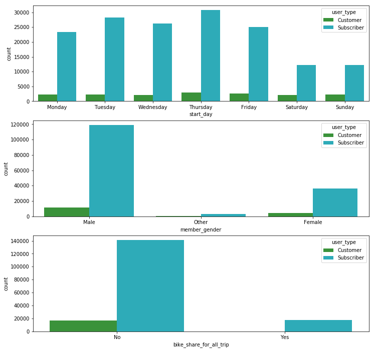

```python
# Plot a clustered bar charts
plt.figure(figsize = [12, 12])
plt.subplot(3,1,1)
sb.countplot(data = fordgobike_df, x = 'start_day', hue = 'user_type',palette= ["#2ca02c", "#17becf"]);
plt.subplot(3,1,2)
sb.countplot(data = fordgobike_df, x = 'member_gender', hue = 'user_type',palette= ["#2ca02c", "#17becf"]);
plt.subplot(3,1,3)
sb.countplot(data = fordgobike_df, x = 'bike_share_for_all_trip', hue = 'user_type',palette= ["#2ca02c", "#17becf"]);
```

As shown in above clustered bar charts.

1. On Thursday, the number of customers and subscribers is more than the rest of the week.
2. Most of customers and subscribers are male.
3. Most of customers and subscribers they don't share a bike for all trip.

### Talk about some of the relationships you observed in this part of the investigation. How did the feature(s) of interest vary with other features in the dataset?

> I observed the following:
> 1. Customers trip duration take longer than subscribers trip duration.
> 2. Female users trip duration take longer than male users trip duration.
> 3. The users who spend more trip duration are between the ages of 18 and 40.
> 4. On Saturday and Sunday, the duration of the trips is longer than the rest of the week.
> 5. Users who don't share a bike have a longer trip duration than those who share bike for all trip.

### Did you observe any interesting relationships between the other features (not the main feature(s) of interest)?

> I observed the following:
> 1. On Thursday, the number of customers and subscribers is more than the rest of the week.
> 2. Most of customers and subscribers are male.
> 3. Most of customers and subscribers they don't share a bike for all trip.
> 4. The number of subscribers is more than customers, but the customers take longer trip duration than the subscribers.
> 5. The number of males is more than females, but the females take longer trip duration than the males.
> 6. The number of trips on Thursday is more than the rest of week, but on Saturday and Sunday, the duration of the trips is longer than the rest of the week.

## Multivariate Exploration

> In this section, we create plots of three or more variables to investigate our data even further by asking the following questions:
> 1. What is the relationship between duration, user age and user type?
> 2. What is the relationship between duration, age and user gender?
> 3. What is the relationship between duration, days of week and user type?
> 4. What is the relationship between duration, days of week and user gender?

I will use ""Question-Visualization-Observations" framework. this framework involves asking a question from the data, creating a visualization to find answers, and then recording observations.

### Question 1: What is the relationship between duration, user age and user type?

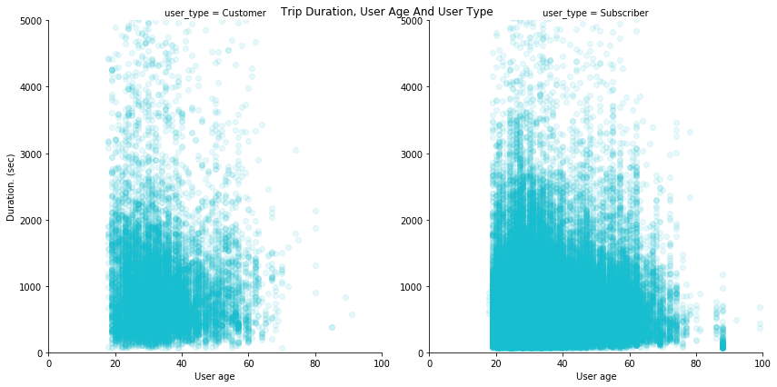

```python
# Plot a scatter plots by using faceting
type_of_user = sb.FacetGrid(data = fordgobike_df, col = 'user_type',size = 6,ylim=[0,5000],xlim=[0,100])
type_of_user.map(plt.scatter,'user_age', 'duration_sec', color=color(),marker="o",alpha=1/10)
type_of_user.fig.suptitle('Trip Duration, User Age And User Type ')
type_of_user.set_ylabels('Duration. (sec)')
type_of_user.set_xlabels('User age')
plt.show()
```

### Question 2: What is the relationship between duration, age and user gender?

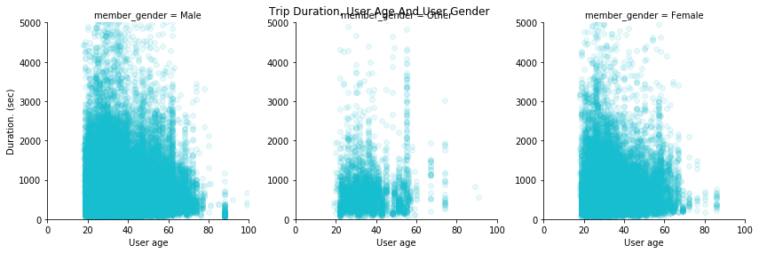

```python
# Plot a scatter plots by using faceting
gender_of_user = sb.FacetGrid(data = fordgobike_df, col = 'member_gender',size = 4,ylim=[0,5000],xlim=[0,100])
gender_of_user.map(plt.scatter,'user_age', 'duration_sec', color=color(),marker="o",alpha=1/10)
gender_of_user.fig.suptitle('Trip Duration, User Age And User Gender')
gender_of_user.set_ylabels('Duration. (sec)')
gender_of_user.set_xlabels('User age')
plt.show()
```

### Question 3: What is the relationship between duration, days of week and user type?

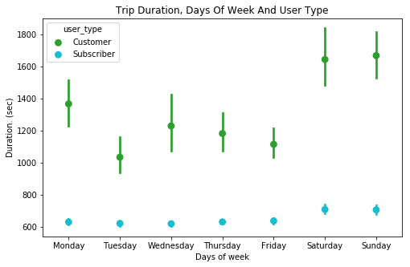

```python
# Plot a line chart
size()
ax = sb.pointplot(data = fordgobike_df, x = 'start_day', y = 'duration_sec', hue = 'user_type',
           palette= ["#2ca02c", "#17becf"],linestyles="")
plt.title('Trip Duration, Days Of Week And User Type')
plt.ylabel('Duration. (sec)')
plt.xlabel('Days of week')
plt.show();
```

As shown in above line plot,

1. In general, customer users have a longer trip duration throughout the week than subscriber users.
2. On Saturday and Sunday, the duration of the trips was longer than the rest of the days of the week for both the subscribers and customers users .

### Question 4: What is the relationship between duration, days of week and user gender?

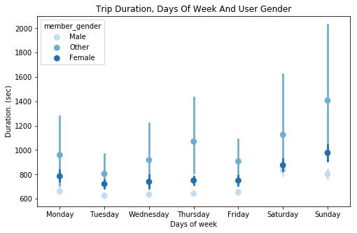

```python
# Plot a line chart
size()
ax = sb.pointplot(data = fordgobike_df, x = 'start_day', y = 'duration_sec', hue = 'member_gender',
           palette= 'Blues',linestyles="")
plt.title('Trip Duration, Days Of Week And User Gender')
plt.ylabel('Duration. (sec)')
plt.xlabel('Days of week')
plt.show();
```

As shown in above line plot,

1. In general, females users have a longer trip duration throughout the week than males users.
2. On Saturday and Sunday, the duration of the trips was longer than the rest of the days of the week for both the females and males users .

### Were there any interesting or surprising interactions between features?

> After completing my observations and investigations, clearly I notice that all the features have normal interactions between them. There is no outstanding relationship between any of the features, because they affect each other in a way or another.